# Spotify Data Exploration

Justin Park, Marcella Anderson, Caitlin Fordell, Desmond Orton, Mario Lloyd Galvao-Wilson, and Brian Sayre

[figure not shown]

## **Introduction**

Music is widely enjoyed around the world but rarely does one question what metrics define *good music*. In such an assesment, one needs to quantify qualities of music. To determine what metrics need to be used an analysis of popularity compared to aspects of music, including but not limited to, energy, liveliness, danceability, et cetera, needs to be considered. The data sets used in this analysis are the “Data from 1921-2021 of songs on Spotify” and “2019 Top 50 Songs on Spotify” which have been taken from Kaggle. “Data from 1921-2021 of songs on Spotify” contains over 175,000 songs spanning from 1912 until 2020. “2019 Top 50 Songs on Spotify” shows the top 50 songs of 2019 from all over the globe. Using these datasets and methods in R, we evaluated top artists from the year based on trends in music related metrics and popularity over time.

## **Research Questions**

To achieve our goal, we have developed general areas of exploration with the following research questions:

#### **1921-2021 Dataset**

- What are the most popular genres based on the data’s popularity ratings?
- What characteristics make up the top genres?
- What are the most frequent genres of the top artists?
- Do the most popular artists align well with the rest of their genre?
- How have energy, liveliness, danceability, duration, speechiness, and tempo changed throughout the years?
- Did the information about the most popular artist during a given year follow the change of energy, liveliness, danceability, duration, speechiness, and tempo?

#### **Top 50 Dataset**

- Are there any highly correlated variables?
- Are there any audio features that most top songs have in common?
- Are ranking or beats per minute affected by popularity?
- What are the most popular genres and artists?

## **Overview of the Dataset**

Two datasets were used in this analysis: “Data from 1921-2021 of songs on Spotify”, “2019 Top 50 Songs on Spotify”. These datasets were gathered from Kaggle but originally scraped from the Spotify public API or organizeyourmusic.playlistmachinery.com. “Data from 1921-2021 of songs on Spotify” contains over 175,000 songs spanning from 1912 until 2020. This data compares songs by their genre, year of release, artist, and so forth. “2019 Top 50 Songs on Spotify” shows the top 50 songs of 2019 from all over the globe. Both datasets contain a combination of categorical and numerical data that can be used for analysis.

#### **Obtaining the dataset**

We obtained both sets of data from Kaggle.  
- The first dataset we used was *Data from 1921-2021 of songs on Spotify* which can be found [here](https://www.kaggle.com/yamaerenay/spotify-dataset-19212020-160k-tracks).  
- The second dataset we used was *2019 Top 50 Songs on Spotify* which can be found [here](https://www.kaggle.com/leonardopena/top50spotify2019).

#### **What is in the dataset**

*Data from 1921-2021 of songs on Spotify*  
This dataset contains over 175,000 songs spanning from 1912 until 2020. This data was collected from the spotifyAPI. This data compares songs by their genre, year of release, artist, and so forth.

*2019 Top 50 Songs on Spotify*  
This dataset shows the top 50 songs of 2019 from all over the globe. The data was originally gathered from http://organizeyourmusic.playlistmachinery.com. The dataset contains 13 different variables.

Our dataset and the code can be found at https://github.com/dorton21/ds202_final

## **Exploratory Analysis**

### **- What are the most popular genres based on the data’s popularity ratings?**

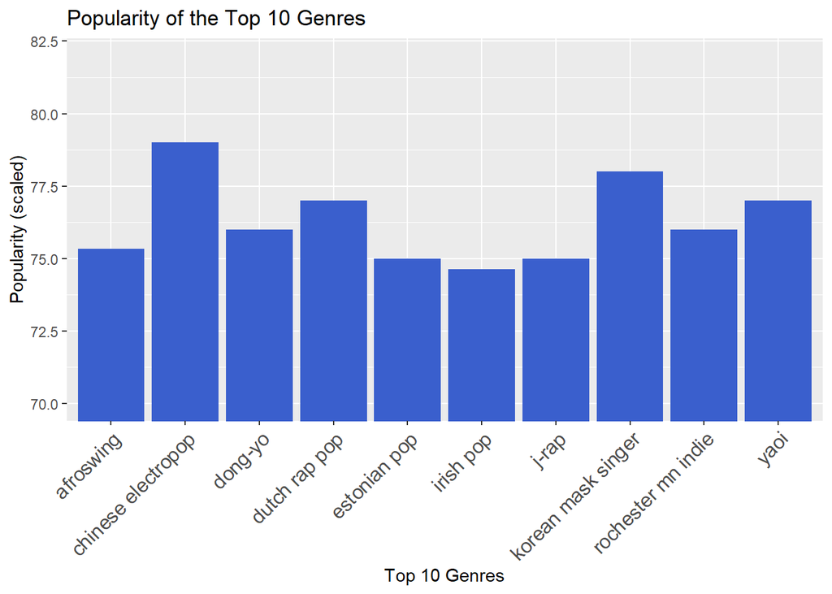

This plot shows the popularity of the top ten genres, using the popularity values given for the genres in the 1921-2021 songs data. This graph is scaled so that only popularity values between 70 and 82 are shown, this is used to better illustrate variation in popularity between each of the ten top genres. The popularity values seen in the given popularity are strange, because some seldom heard of genres are the top genres. For example, chinese electropop is the most popular music genre even though most people could not name a song in that genre. It has been hypothesized that this is the top genre due to China being the most populated country, but our data comes from Spotify which is not available in China, making this hypothesis unlikely. Since the results do not make much sense there must be a different way to look at the data and better determine the top genres, this is tackled later in our report.

### **- What characteristics make up the top genres?**

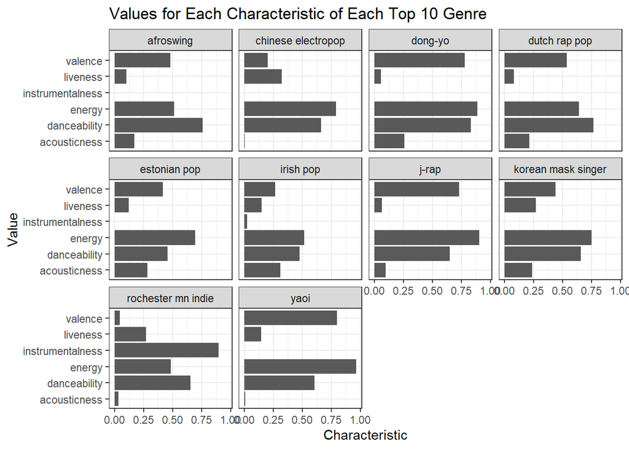

### **- What are the most frequent genres of the top artists?**

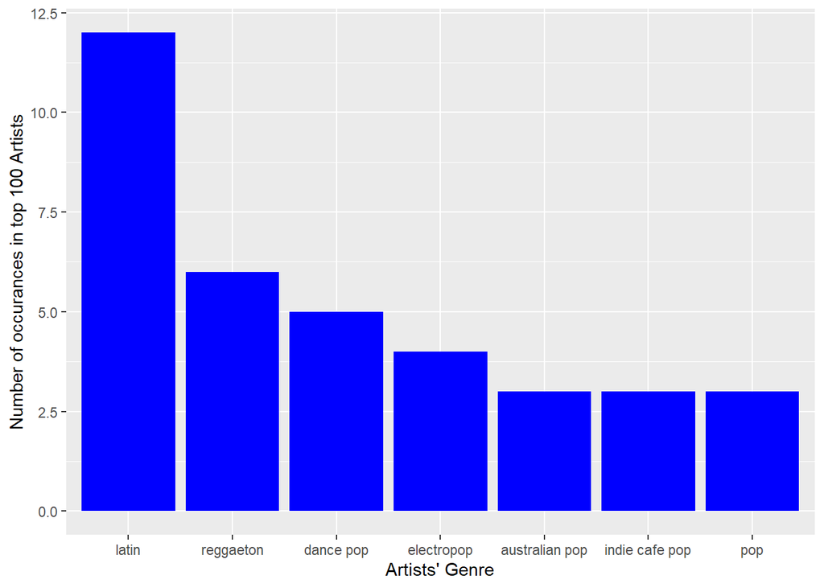

We can see from the plot the top 7 genres of artists currently in the top 100. The results surprised me a little bit at first until I remember that this data is world-wide so it would make sense that the most popular in the use, like dance pop and pop, aren’t necessarily the top in the whole world.

### **- Do the most popular artists align well with the rest of their genre?**

Plot the top artists of the latin and pop genres to compare their features with their genre’s average.

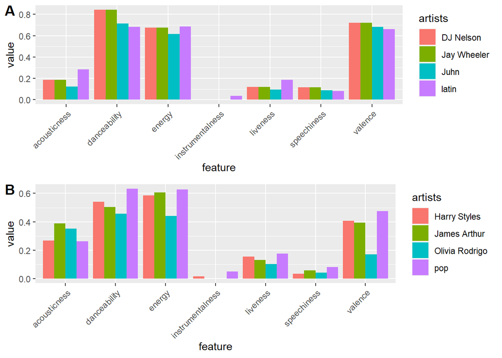

### **- How have energy, liveliness, danceability, duration, speechiness, and tempo changed throughout the years?**

The following graphs show the change in energy, liveliness, danceability, duration, speechiness, and tempo throughout the year. Every metric has change widely throughout the years and has not followed any specfic pattern. Some metrics have risen while other metrics have fallen. There is also heavy up and down fluctuation throughout each year but each metric has some large overall trend. Look at the change in acousticness, for example, despite large fluctuations year-to-year, there is an overall downward trend for the data.

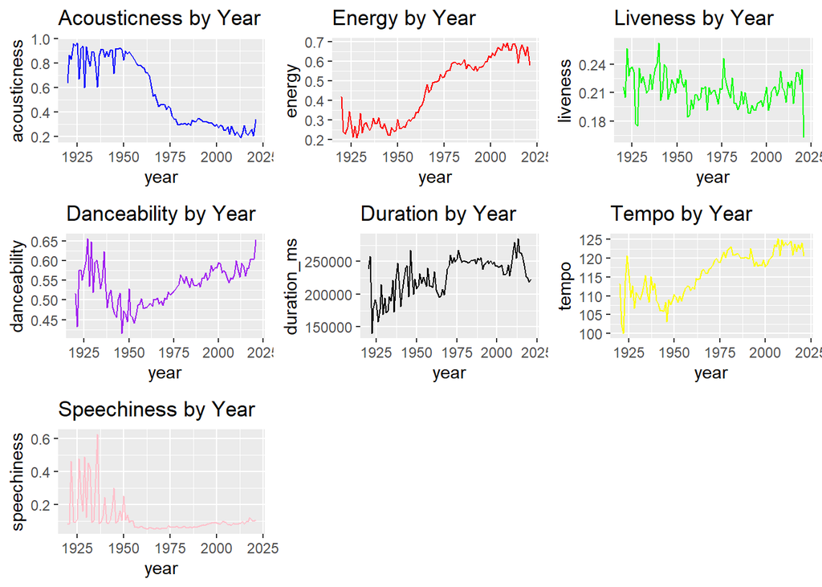

### **- Did the information about the most popular artist during a given year follow the change of energy, liveliness, danceability, duration, speechiness, and tempo?**

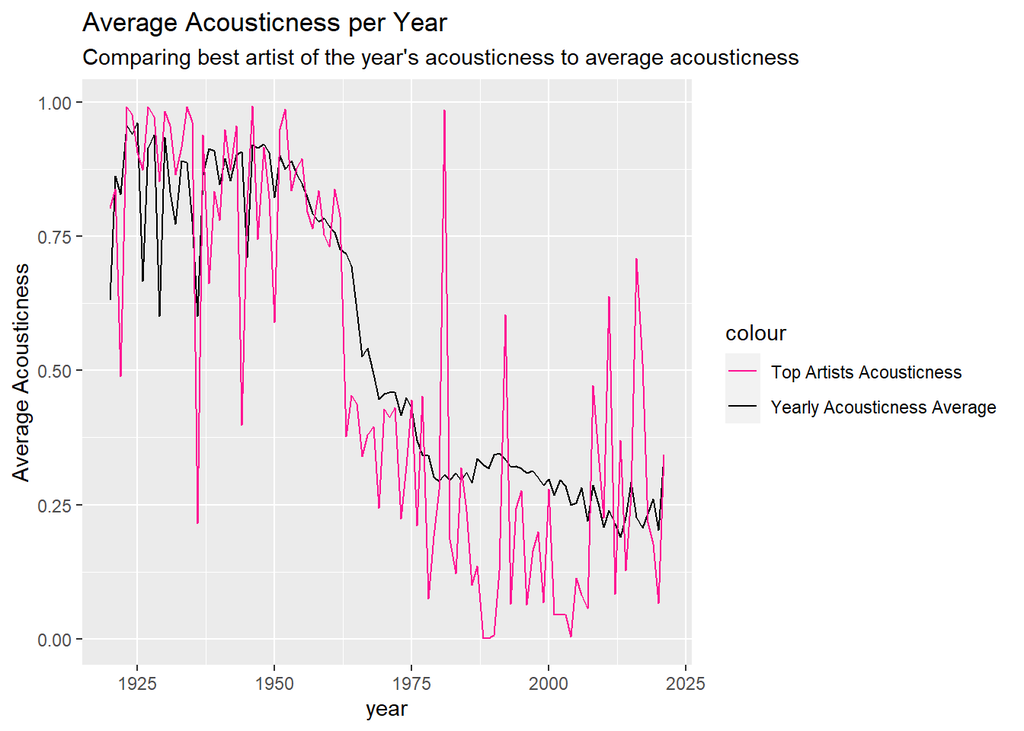

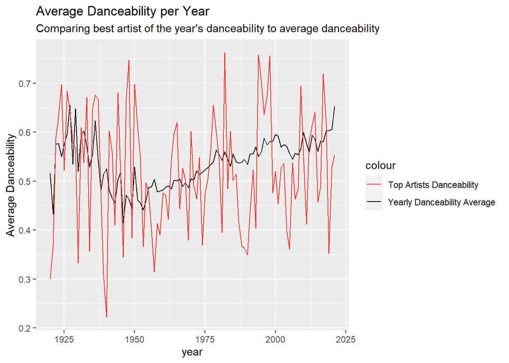

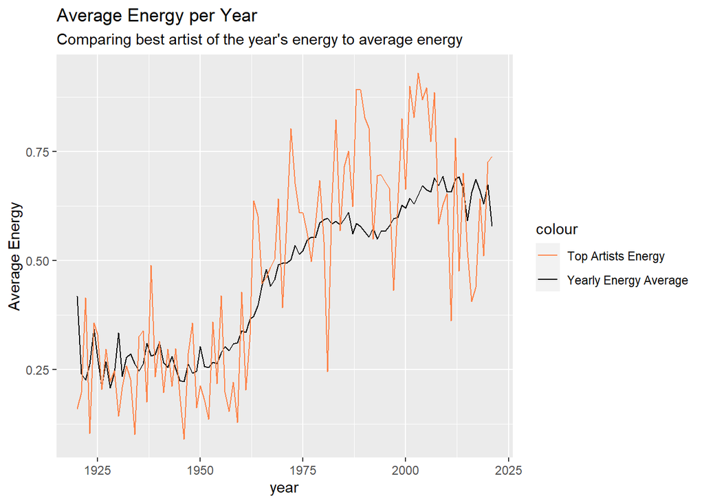

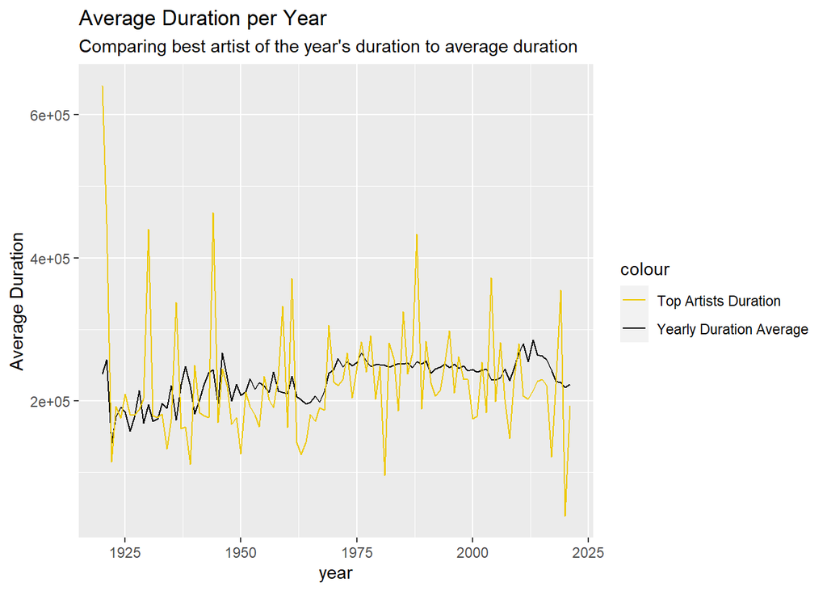

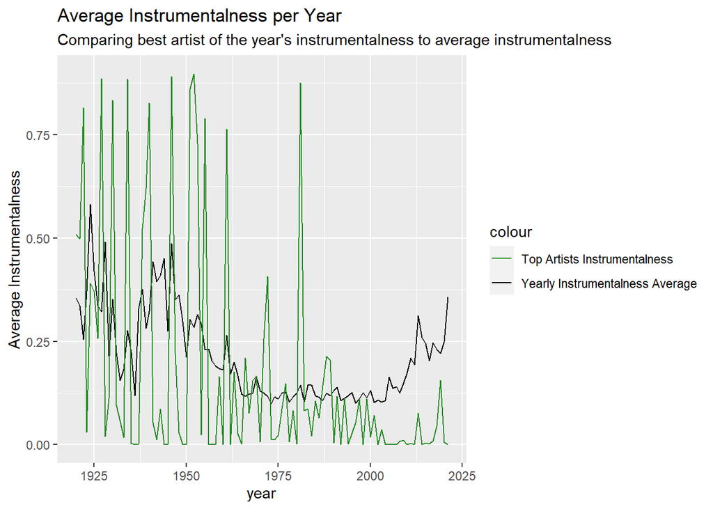

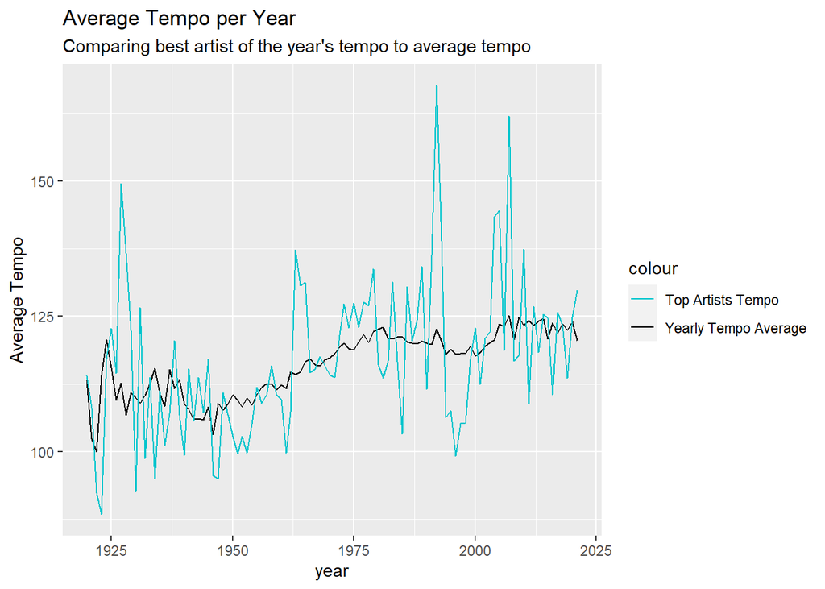

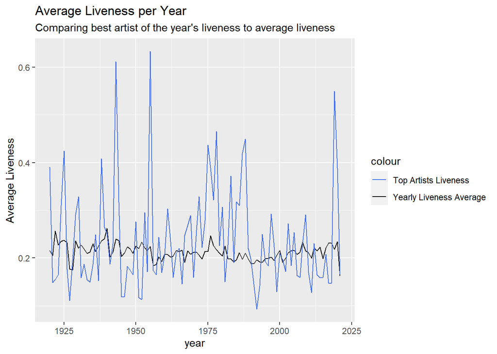

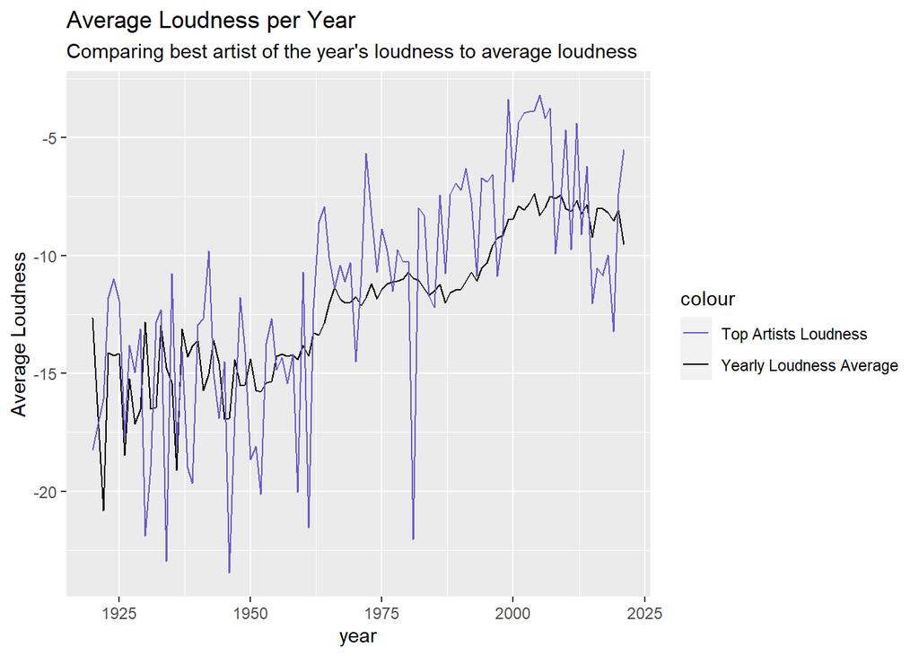

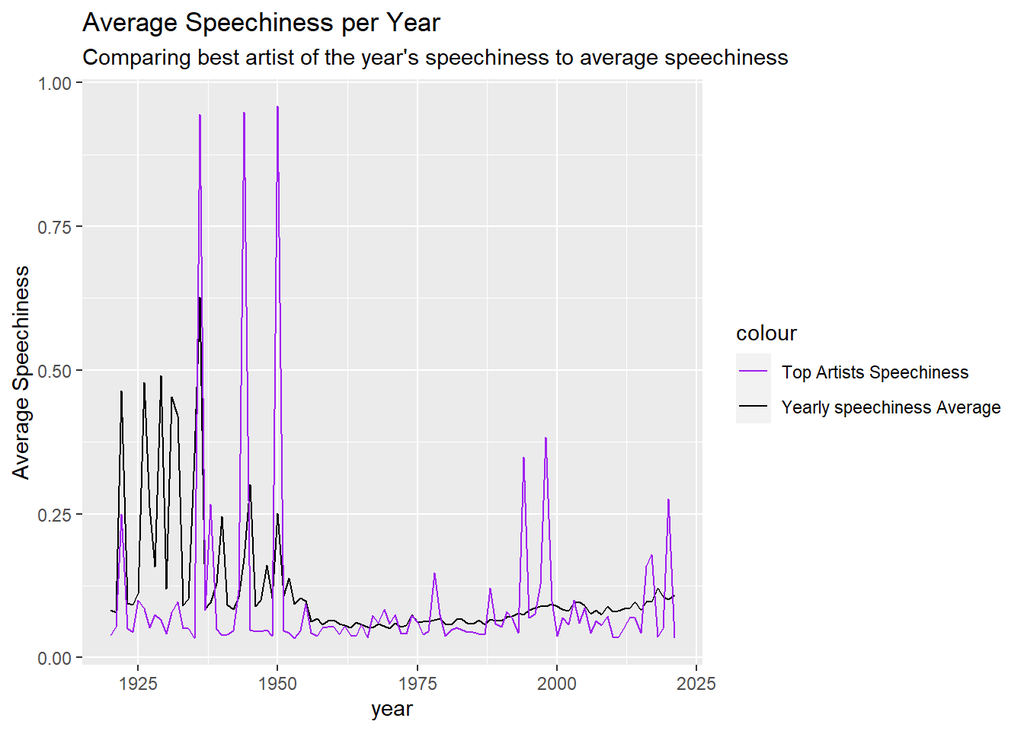

### **- Are there any highly correlated variables?**

```
##                            X Beats.Per.Minute      Energy  Danceability
## X                 1.00000000      -0.25919258  0.10264874  0.1226909159
## Beats.Per.Minute -0.25919258       1.00000000  0.04375559 -0.0941828916
## Energy            0.10264874       0.04375559  1.00000000  0.0182535758
## Danceability      0.12269092      -0.09418289  0.01825358  1.0000000000
## Loudness..dB..    0.01191365       0.01701619  0.67079357  0.0162545370
## Liveness          0.27065950      -0.16728576  0.16276771 -0.1496362023
## Valence.          0.13732859      -0.01158582  0.43881959  0.1728289768
## Length.          -0.06584372      -0.13928840  0.22467681 -0.0001852976
## Acousticness..   -0.01599309      -0.03144960 -0.33989165 -0.0981653774
## Speechiness.     -0.25750585       0.55705188 -0.08985967 -0.1034719217
## Popularity       -0.16068037       0.19609692 -0.08029497 -0.0714132526
##                  Loudness..dB..    Liveness    Valence.       Length.
## X                    0.01191365  0.27065950  0.13732859 -0.0658437232
## Beats.Per.Minute     0.01701619 -0.16728576 -0.01158582 -0.1392883997
## Energy               0.67079357  0.16276771  0.43881959  0.2246768064
## Danceability         0.01625454 -0.14963620  0.17282898 -0.0001852976
## Loudness..dB..       1.00000000  0.25865203  0.23761380  0.2192187407
## Liveness             0.25865203  1.00000000  0.01612347  0.1317823354
## Valence.             0.23761380  0.01612347  1.00000000 -0.0177817772
## Length.              0.21921874  0.13178234 -0.01778178  1.0000000000
## Acousticness..      -0.13829961  0.02132824 -0.05232331 -0.0762926901
## Speechiness.        -0.27221263 -0.12528606 -0.05324175  0.0467552609
## Popularity          -0.04308543  0.09256423 -0.31775236 -0.0876388589
##                  Acousticness.. Speechiness.  Popularity
## X                  -0.015993085 -0.257505853 -0.16068037
## Beats.Per.Minute   -0.031449597  0.557051878  0.19609692
## Energy             -0.339891653 -0.089859668 -0.08029497
## Danceability       -0.098165377 -0.103471922 -0.07141325
## Loudness..dB..     -0.138299607 -0.272212633 -0.04308543
## Liveness            0.021328241 -0.125286062  0.09256423
## Valence.           -0.052323306 -0.053241746 -0.31775236
## Length.            -0.076292690  0.046755261 -0.08763886
## Acousticness..      1.000000000  0.008293376 -0.03468404
## Speechiness.        0.008293376  1.000000000  0.23855303
## Popularity         -0.034684041  0.238553032  1.00000000
```

Energy and Loudness..db.. have a moderately strong correlation of 0.671, which means that they express a lot of similar information. Also, Speechiness. and Beats.Per.Minute have a moderately strong correlation of 0.557.

### **- Are there any audio features that most top songs have in common?**

```
##        X         Beats.Per.Minute     Energy       Danceability
##  Min.   : 1.00   Min.   : 85.0    Min.   :32.00   Min.   :29.00
##  1st Qu.:13.25   1st Qu.: 96.0    1st Qu.:55.25   1st Qu.:67.00
##  Median :25.50   Median :104.5    Median :66.50   Median :73.50
##  Mean   :25.50   Mean   :120.1    Mean   :64.06   Mean   :71.38
##  3rd Qu.:37.75   3rd Qu.:137.5    3rd Qu.:74.75   3rd Qu.:79.75
##  Max.   :50.00   Max.   :190.0    Max.   :88.00   Max.   :90.00
##  Loudness..dB..      Liveness        Valence.        Length.
##  Min.   :-11.00   Min.   : 5.00   Min.   :10.00   Min.   :115.0
##  1st Qu.: -6.75   1st Qu.: 8.00   1st Qu.:38.25   1st Qu.:176.8
##  Median : -6.00   Median :11.00   Median :55.50   Median :198.0
##  Mean   : -5.66   Mean   :14.66   Mean   :54.60   Mean   :201.0
##  3rd Qu.: -4.00   3rd Qu.:15.75   3rd Qu.:69.50   3rd Qu.:217.5
##  Max.   : -2.00   Max.   :58.00   Max.   :95.00   Max.   :309.0
##  Acousticness..   Speechiness.     Popularity
##  Min.   : 1.00   Min.   : 3.00   Min.   :70.00
##  1st Qu.: 8.25   1st Qu.: 5.00   1st Qu.:86.00
##  Median :15.00   Median : 7.00   Median :88.00
##  Mean   :22.16   Mean   :12.48   Mean   :87.50
##  3rd Qu.:33.75   3rd Qu.:15.00   3rd Qu.:90.75
##  Max.   :75.00   Max.   :46.00   Max.   :95.00
```

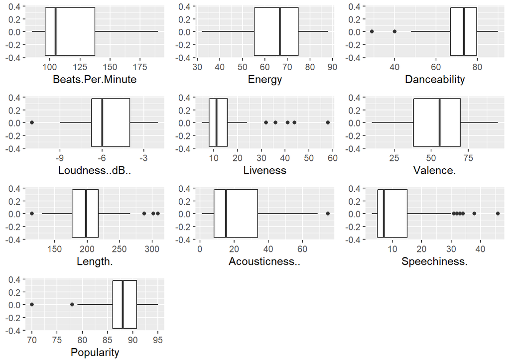

Common Features: Medium to high energy, high danceability, relatively loud, not likely to be live, equal range of valence, around 2-4 minutes long, not very acoustic, very little spoken words, and pretty high popularity ratings.

Beats.Per.Minute has a mean of 120.1 beats per minute and had a very skewed right distribution. In general, the Top 50 songs had relatively high tempos.

Energy has a mean of 64.06 and is slightly skewed to the left. Overall, the Top 50 songs had a tendency to be moderately to high energy songs.

Danceability has a mean of 71.38 and is very skewed to the left. Overall, the Top 50 songs were very easy to dance to according to the danceability rating.

Loudness..dB.. has a mean of -5.66 is relatively symmetric. The Top 50 songs tended to be relatively loud songs as the mean is close to 0.

Liveness has a mean of 14.66 and is very skewed to the right. This means that the Top 50 tracks were generally not very likely to be live tracks recorded.

Valence. has a mean of 54.6, a range from 10 to 95, and is bimodal but pretty symmetric. Valence reflects the overall positive mood of a song. Since the range of valence is so large and given the distribution, we see that the Top 50 songs included both positive and negative moods. Since the mean was 54.6 and the distribution was bimodal, we could say that the Top 50 songs equally represent positive and negative moods.

Length. has a mean of 201 seconds and is symmetric.

Acousticness.. has a mean of 22.16 and is skewed to the right. Generally, the Top 50 songs tended to not be very acoustic.

Speechiness. has a mean of 12.48 and is skewed to the right. Since the mean of speechiness is so low, the Top 50 songs did not commonly include many spoken words.

Popularity has a mean of 87.5 and is skewed to the left. Since the high value for popularity is 100, it makes sense that the Top 50 songs of the year had high popularity ratings.

### **- Are ranking or beats per minute affected by popularity?**

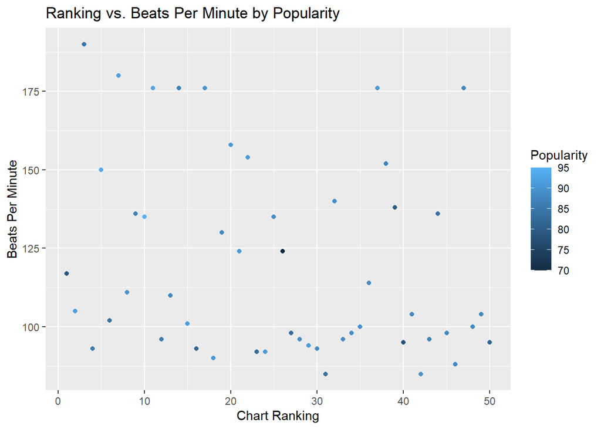

There does not appear to be a significant correlation between popularity and ranking or between beats per minute and popularity. The #1 song actually has one of the lowest popularity ratings, meaning that popularity is not necessarily the best indicator of ranking.

### **- What are the most popular genres?**

```
## # A tibble: 21 x 2
##    Genre            Popularity
##    <chr>                 <dbl>
##  1 dfw rap                92.5
##  2 electropop             92
##  3 trap music             92
##  4 escape room            91
##  5 pop house              91
##  6 reggaeton              91
##  7 latin                  89.8
##  8 canadian hip hop       89.7
##  9 atl hip hop            89
## 10 big room               89
## # ... with 11 more rows
```

The genres in the top 50 dataset from 2019 mostly contains pop or rap songs. This is very different from the previous dataset that we used earlier that had more of a variety of genres. I believe these genres represent the young population in the United States. Since younger people (teenagers and young adults) tend to use streaming platforms like Spotify more, their music choices will reflect more on the top 50 songs than any other generation.

### **- Who are the most popular artists?**

```
## # A tibble: 38 x 2
##    Artist.Name   Popularity
##    <chr>              <dbl>
##  1 Bad Bunny           93
##  2 Post Malone         92.5
##  3 Anuel AA            92
##  4 Billie Eilish       92
##  5 Drake               92
##  6 Lil Tecca           92
##  7 Daddy Yankee        91
##  8 Lizzo               91
##  9 Lunay               91
## 10 MEDUZA              91
## # ... with 28 more rows
```

The top three artists in this dataset were Bad Bunny, Post Malone, and Anuel AA. The top artists of 2019 go hand in hand with the top genres since these names tend to product pop or rap music.

## **Conclusion**

In conclusion, we found that top artists tended to be singers who did align with peers in their genre for most features. However, we could see some new trends in those genres by comparing the currently popular artists with the rest of the genres. Also, we showed that over time, there were major changes in the musical characteristics of the most popular songs (these trends were shown in time series analysis). Additionally, we found that 2019 music seemed to favor upbeat and danceable songs that were not very acoustic or live. In particular, the artists Bad Bunny and Post Malone were very influential in 2019.

## **Personal Contributions**

Our Github repository can be found at https://github.com/dorton21/ds202_final

#### **Justin Park**

Justin worked on the questions “What are the most popular genres?” and “Who are the most popular artists?”. He also helped with putting together the final report and presentation.

#### **Marcella Anderson**

Marcy worked on analyzing how artists’ sound changes over the year. She also looked at how the different feature have changed over the year. Along with that analysis she worked one the presentation and final report.

#### **Caitlin Fordell**

Caitlin worked on the questions “Are there any highly correlated variables?”, “Are there any audio features that most top songs have in common?”, and “Are ranking or beats per minute affected by popularity?” along with development of the proposal, presentation, and final report.

#### **Desmond Orton**

Desmond contributed on the writing of the proposal, writing of the final report, R code analysis, creation of the powerpoint, and presentation of the final project.

#### **Mario Lloyd Galvao-Wilson**

In addition to the finalized code above, Mario helped with data acquisition, proposal brainstorming, presentation slides, final report, and the final presentation.

#### **Brian Sayre**

Brian worked on the questions “What are the most frequent genres of the top artists?” and “Do the most popular artists align well with the rest of their genre?”. Along with eveyone else he helped put together the final repost and presentation.